# Predicting Success of a Movie - Data Visualization

Madhusudan

11/2021

```r
library("tidyverse")
```

```r
library("ggplot2")
```

```r
#Importing the cleaned data
Cleaned_data <- as_tibble(read_csv("cleaned_movies_database.csv"))
```

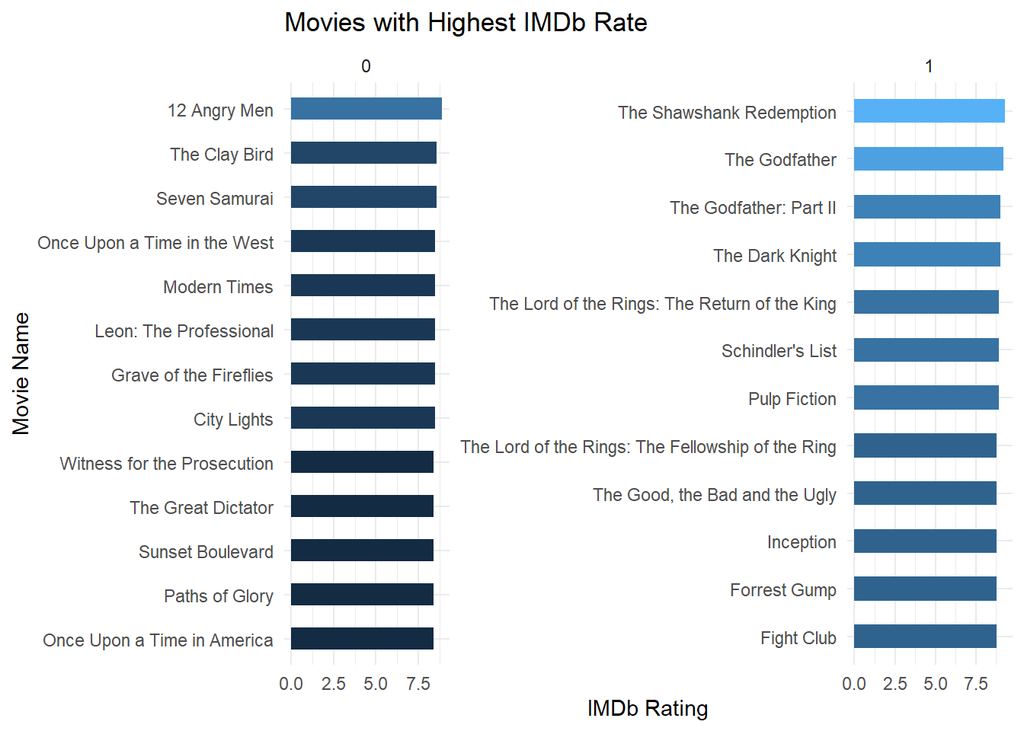

```r
#The top 20 Movies with High IMDb Ratings, For  hit and not hit movies

Cleaned_data %>%
  group_by(hit) %>%
  top_n(10,wt=weighted_average_vote) %>%
  summarise(title, weighted_average_vote,hit) %>%
  arrange(desc(weighted_average_vote)) %>%
  ggplot(aes(x=reorder(title, weighted_average_vote), y=weighted_average_vote, fill=weighted_average_vote))+
  geom_col(width=0.5 ,show.legend = FALSE)+
  facet_wrap(~hit,scales = 'free')+
  coord_flip()+
  labs(x="Movie Name", y="IMDb Rating", title = "Movies with Highest IMDb Rate")+
  theme_minimal()
```

From the above Figure we can see that the hit movies, have higher IMDb ratings compared to the non-hit movies

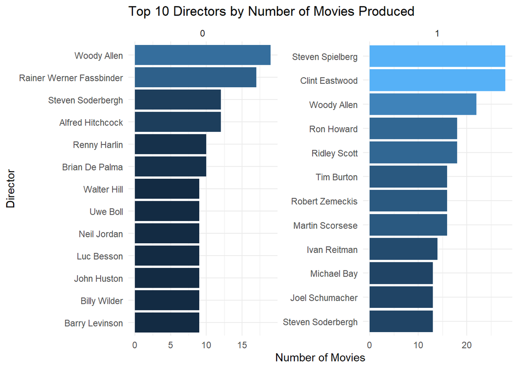

```r
#Top 10 directors for hit and not hit movies

Cleaned_data %>%
  group_by(hit) %>%
  count(director, sort=TRUE) %>%
  top_n(10)%>%
  ggplot(aes(x=reorder(director, n), y=n, fill=n)) +
  geom_col(show.legend = FALSE) +
  facet_wrap(~hit,scales = 'free')+
  labs(x="Director", y="Number of Movies",title="Top 10 Directors by Number of Movies Produced") +
  coord_flip() +
  theme_minimal()
```

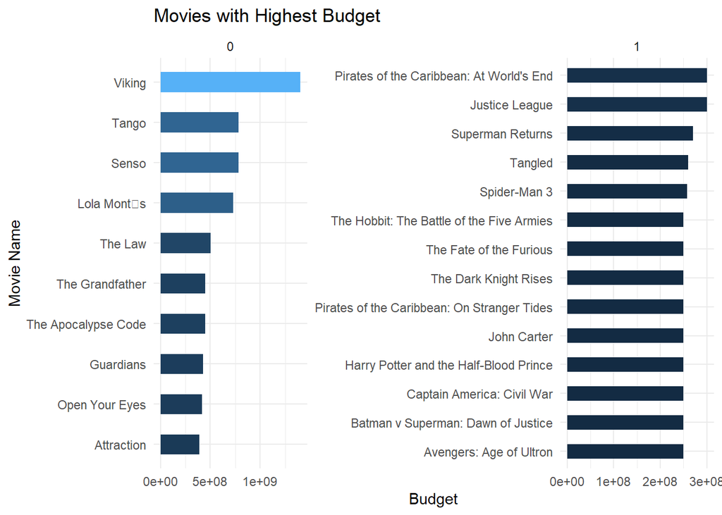

```r
#Movies with Highest budget faceted by hit or not hit

Cleaned_data %>%
  mutate(title = str_replace_all(title,"[^[:graph:]]", " ")) %>%
  group_by(hit) %>%
  top_n(10,wt=budget) %>%
  summarise(title, budget,hit) %>%
  arrange(desc(budget)) %>%
  ggplot(aes(x=reorder(title, budget), y=budget, fill=budget))+
  geom_col(width=0.5 ,show.legend = FALSE)+
  facet_wrap(~hit,scales = 'free')+
  coord_flip()+
  labs(x="Movie Name", y="Budget", title = "Movies with Highest Budget") +
  theme_minimal()
```

It can be see that the top 10 movies in terms of budget, have higher budget for non-hit movies than hit movies

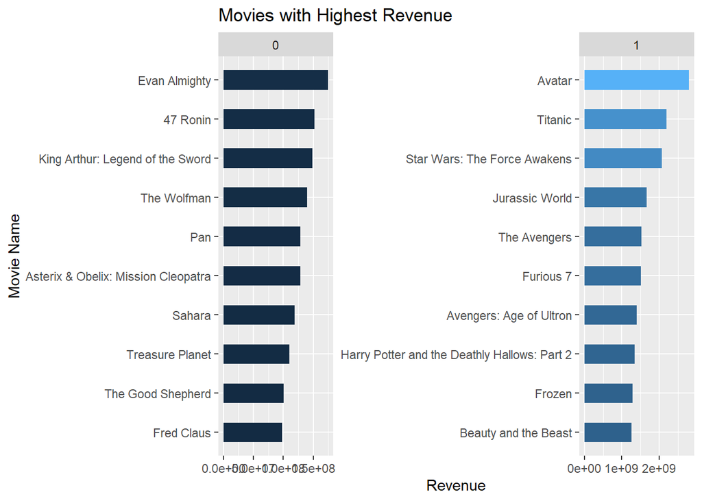

```r
#Movies with Highest Revenues faceted by hit or not hit

Cleaned_data %>%
  mutate(title = str_replace_all(title,"[^[:graph:]]", " ")) %>%
  group_by(hit) %>%
  top_n(10,wt=worlwide_gross_income) %>%
  summarise(title, worlwide_gross_income,hit) %>%
  arrange(desc(worlwide_gross_income)) %>%
  ggplot(aes(x=reorder(title, worlwide_gross_income), y=worlwide_gross_income, fill=worlwide_gross_income))+
  geom_col(width=0.5 ,show.legend = FALSE)+
  facet_wrap(~hit,scales = 'free')+
  coord_flip()+
  labs(x="Movie Name", y="Revenue", title = "Movies with Highest Revenue") +
  theme()
```

It can be see that the top 10 movies in terms of revenue, have higher revenue for hit movies than non-hit movies

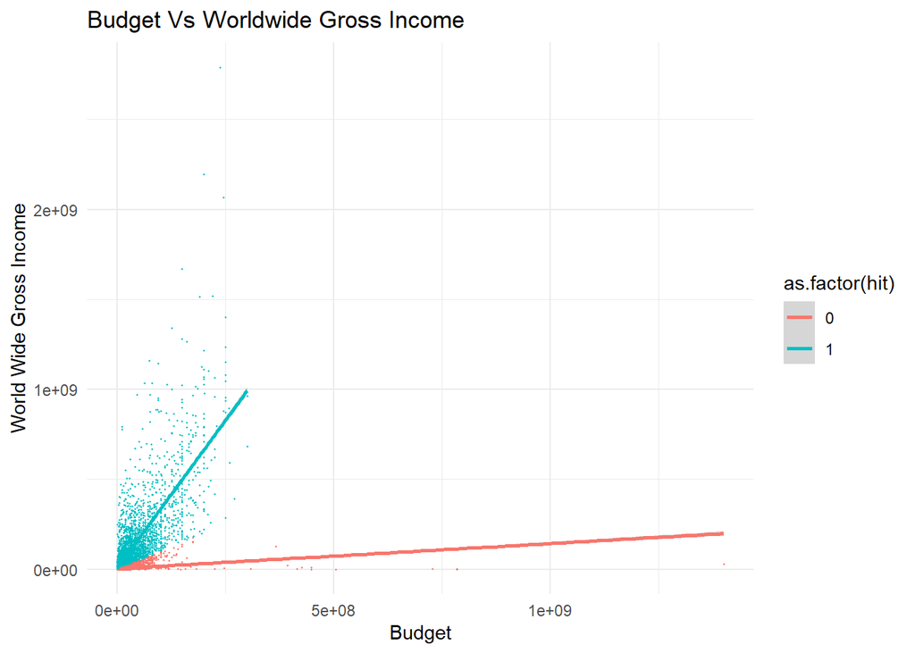

```r
#Scatter plot to see if there is any relationship between budget and worldwide gross income faceted by hit or not hit movie

Cleaned_data %>%
  ggplot(mapping = aes(x = budget, y = worlwide_gross_income, color = as.factor(hit))) +
  geom_point(size = 0.2) +
  geom_smooth(method = lm) +
  labs(x="Budget", y="World Wide Gross Income", title= "Budget Vs Worldwide Gross Income")+
  scale_fill_discrete(name = "Hit Movie") +
  theme_minimal()
```

From the above we can see that the revenue and budget both increase for hit movies. However, for non-hit movies, the increasing budget does not increase the revenue after a certain point, which is expected

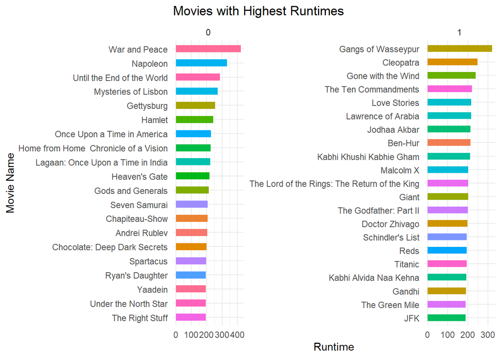

```r
#Movies with highest run times in terms of hit and non hit
Cleaned_data %>%
  group_by(hit)%>%
  top_n(20,wt=runtime) %>%
  summarise(title, runtime, hit) %>%
  arrange(desc(runtime))%>%
  ggplot(aes(x=reorder(title,runtime), y=runtime, fill=title))+
  geom_col(width=0.5 ,show.legend = FALSE)+
  facet_wrap(~hit,scales = 'free')+
  coord_flip()+
  labs(x="Movie Name", y="Runtime", title = "Movies with Highest Runtimes") +
  theme_minimal()
```

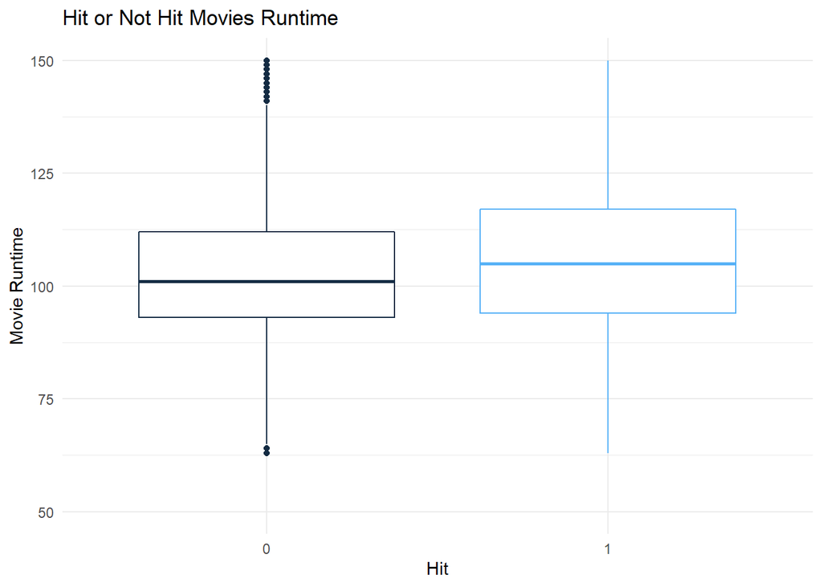

```r
#Run time of hit and not-hit movies

Cleaned_data %>%
  ggplot(mapping = aes(x = as.factor(hit), y=runtime, color= hit)) +
  geom_boxplot(show.legend = "False") +
  labs(y="Movie Runtime",x = "Hit", title= "Hit or Not Hit Movies Runtime")+
  ylim(50,150)+
  theme_minimal()
```

From the above boxplots we can see that the run-times are mostly similar for both hit and non-hit movies

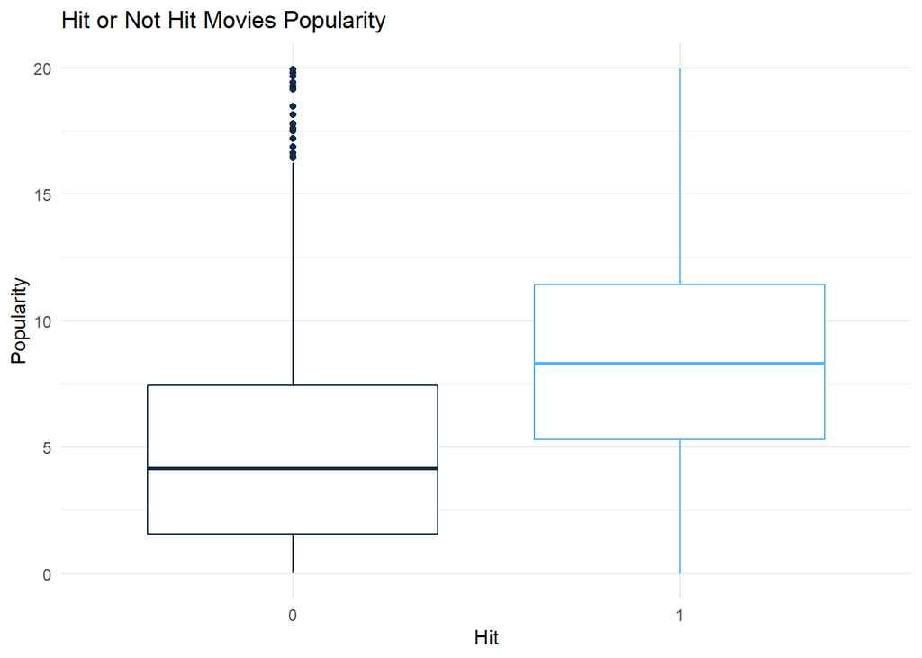

```r
#Popularity Score of hit and not-hit movies

Cleaned_data %>%
  ggplot(mapping = aes(x = as.factor(hit), y=popularity, color= hit)) +
  geom_boxplot(show.legend = "False") +
  labs(y="Popularity",x = "Hit", title= "Hit or Not Hit Movies Popularity")+
  ylim(0,20)+
  theme_minimal()
```

From the above boxplots we can see that that the popularity score for hit movies is significantly higher compared to that of non-hit movies

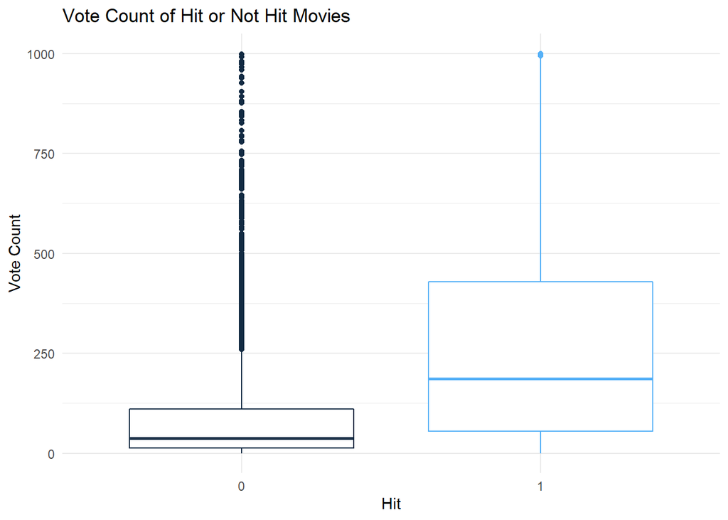

```r
#Vote Count of hit and not-hit movies

Cleaned_data %>%
  ggplot(mapping = aes(x = as.factor(hit), y=vote_count, color= hit)) +
  geom_boxplot(show.legend = "False") +
  labs(y="Vote Count",x = "Hit", title= "Vote Count of Hit or Not Hit Movies")+
  ylim(0,1000)+
  theme_minimal()
```

From the above boxplots we can see that that the vote count for hit movies is significantly higher compared to that of non-hit movies

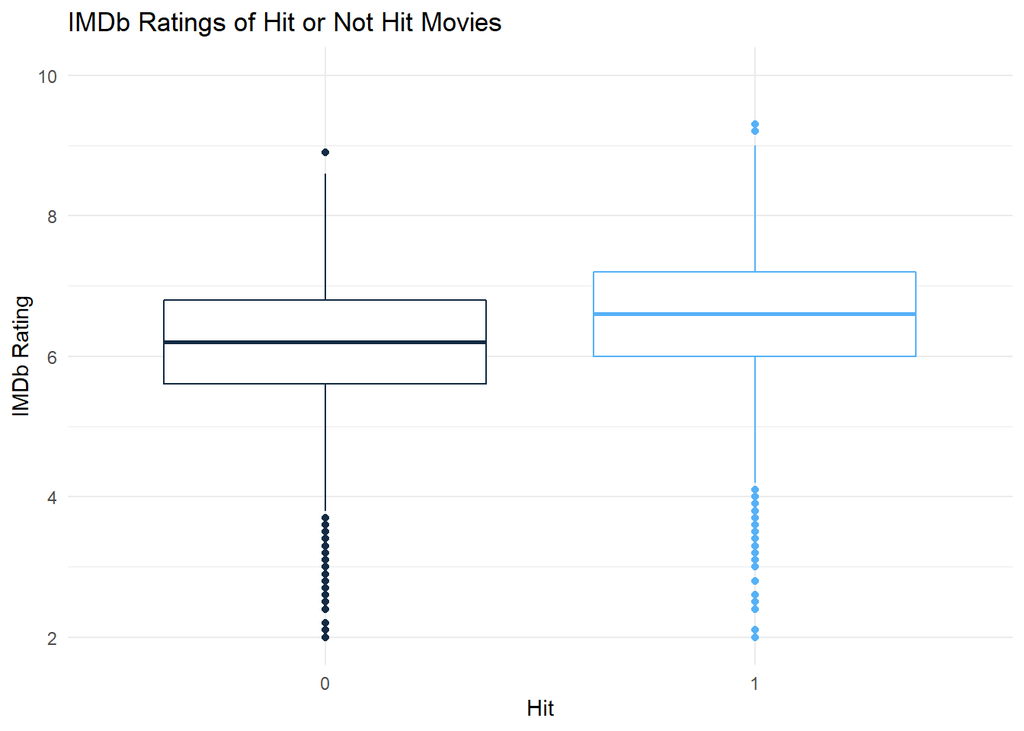

```r
#IMDB Ratings of hit and not-hit movies

Cleaned_data %>%
  ggplot(mapping = aes(x = as.factor(hit), y=weighted_average_vote, color= hit)) +
  geom_boxplot(show.legend = "False") +
  labs(y="IMDb Rating",x = "Hit", title= "IMDb Ratings of Hit or Not Hit Movies")+
  ylim(2,10)+
  theme_minimal()
```

From the above boxplots we can see that that the IMDB Ratings for hit movies is slightly higher compared to that of non-hit movies

[figure not shown]

```r
#Popularity vs IMDB Ratings

Cleaned_data %>%
  ggplot(mapping = aes(x =weighted_average_vote, y = popularity)) +
  geom_point(size=0.2)+
  facet_wrap(~hit) +
  labs(x="IMDb Rating",y="Popularity", title = "Popularity Vs IMDb Ratings for Hit and Not Movies")+
  geom_smooth()+
  theme_minimal()
```

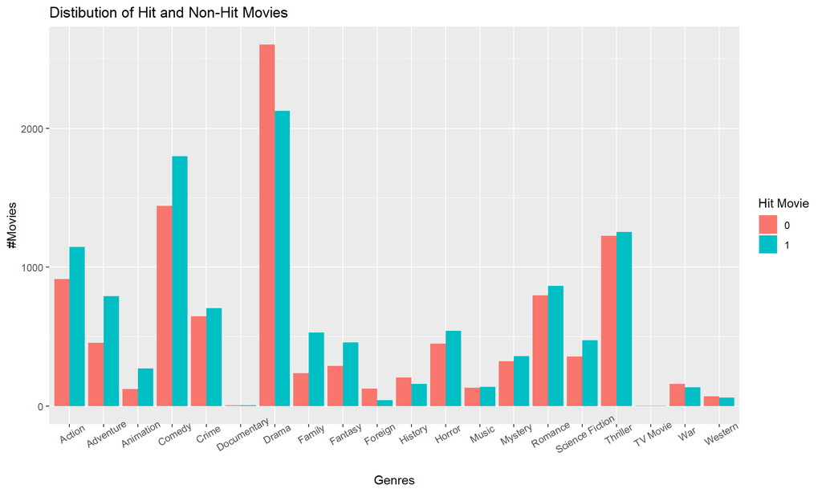

```r
#Impact of Genre

Cleaned_data %>%
  select(c(imdb_id, 126:145, hit)) %>%
  gather('genre','has_genre',2:21) %>%
  filter(has_genre == 1) %>%
  ggplot(mapping = aes(x = genre)) +
  geom_bar(aes(fill = as.factor(hit)), position = 'dodge') +
  theme(axis.text.x = element_text(angle = 30)) +
  labs(x = 'Genres', y = '#Movies', title = 'Distibution of Hit and Non-Hit Movies') +
  scale_fill_discrete(name = "Hit Movie")
```

As seen from the above graph, Genre `Drama` has significantly higher number of non-hit movies, when compared to other genres. On the other hand, genres `Action`, `Adventure`, `Animation`,`Comedy`, `Family`, `Fantasy` have higher number of hit movies, compared to Non-hit movies